# Parameter Estimation and Likelihood

Steve Elston

10/02/2023”

## Review

Sampling is a fundamental process in the collection and analysis of data

- Sampling is important because we almost never have data on a whole population
- Sampling must be randomized to preclude biases
- As sample size increases the standard error of a statistic computed from the sample decreases by the law of large numbers
- Key points to keep in mind:
  - Understanding sampling is essential to ensure data is representative of the entire population
  - Use inferences on the sample to say something about the population
  - The sample must be randomly drawn from the population
- Sampling from distribution is the building block of simulation

## Review

Sampling of a population is done from an unknown **population distribution**, $\mathcal{F}$

- Any statistic we compute for the generating process is an approximation for the population, $s(\hat{\mathcal{F}})$

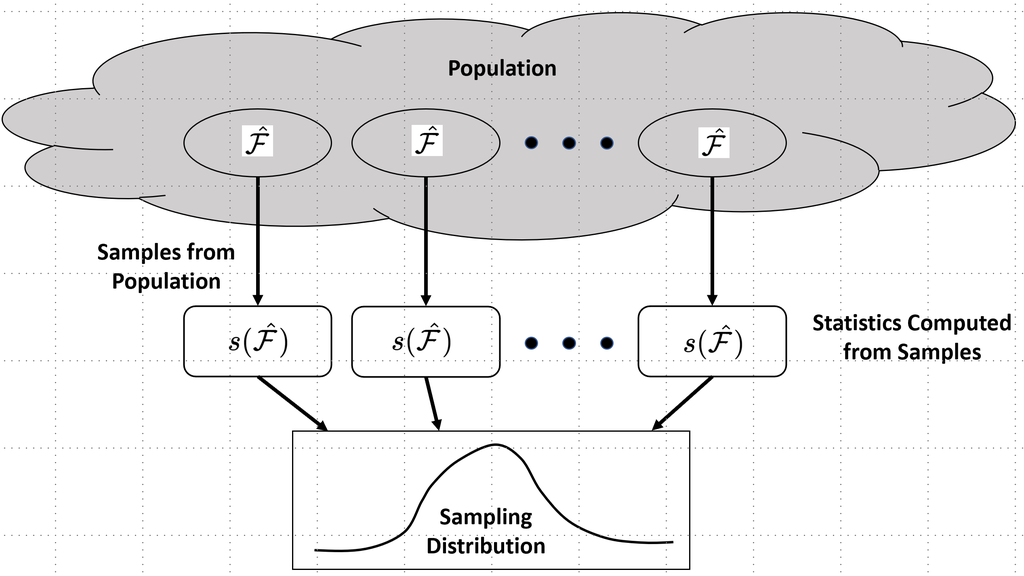

Sampling distribution of unknown population parameter

## Review

The **law of large numbers** is a theorem that states that **statistics of independent random samples converge to the population values as more samples are used**

- The law of large numbers is foundational to statistics and sampling theory
- Assume that **larger samples are more representatives of the population we are sampling**
- If the real world did not follow this theorem much of statistics, to say nothing of science and technology, would fail badly.

## Introduction

The concept of **likelihood** and **maximum likelihood estimation (MLE)** have been at the core of much of statistical modeling for about 100 years

- In 21st Century, likelihood and MLE continue to be foundational
- Understanding the concept of likelihood and the use of MLE methods is key to understanding many parametric statistical methods
- Likelihood is a measure of how likely a parametric model is to generate the observed data
- MLE is a generic methods for parameter estimation
- MLE used widely for machine learning models, including some deep learning models

## Likelihood and Density Functions

Likelihood is a measure of how likely a **parametric model** is to generate the observed data

- Start with a data sample, $\mathbf{X} = [x_1, x_2, \ldots, x_n]$
- Likelihood of sample from a **data generating process** with a **parametric density function**, $f(\mathbf{X} | \theta)$
  - $f(\mathbf{X}\ |\ \mathbf{\theta})$ can be either a probability density function (PDF), for continuous distributions, or a probability mass function (PMF), for discrete distributions
  - The distribution parameter vector, $\mathbf{\theta}$, is fixed
- Now, for each observation, $x_i$, in $\mathbf{X} = x_1, x_2, \ldots, x_n$, the density is just $f(x_i |\ \mathbf{\theta})$

## Likelihood

Likelihood is a measure of how likely a **parametric model** is to generate the observed data

- Likelihood of sample from a **data generating process** with a **parametric probability density**, $f(\mathbf{X} | \theta)$
- For the set of observations, $\mathbf{X} = [x_1, x_2, \ldots, x_n]$, the likelihood is the product of the densities:

$$\mathcal{L}(\mathbf{X} |\
\mathbf{\theta}) = \prod_{i=1}^n f(x_i | \mathbf{\theta})$$

- In most practical cases, we work with the **log likelihood**, for observations, $\mathbf{X} = x_1, x_2, \ldots, x_n$, the log likelihood is expressed:

$$l(\mathbf{X} |\ \mathbf{\theta}) =
log\big( \mathcal{L}(\mathbf{X} |\ \mathbf{\theta}) \big) = \sum_{i=1}^n
log \Big( f(x_i\ |\ \mathbf{\theta}) \Big)$$

## Likelihood

Likelihood is a measure of how likely a **parametric model** is to generate the observed data sample

- In most practical cases, we work with the **log likelihood**, for observations, $\mathbf{X} = x_1, x_2, \ldots, x_n$, the log likelihood is expressed:

$$l(\mathbf{X} |\ \mathbf{\theta}) =
log\big( \mathcal{L}(\mathbf{X} |\ \mathbf{\theta}) \big) = \sum_{i=1}^n
log \Big( f(x_i\ |\ \mathbf{\theta}) \Big)$$

- Use log-likelihood to work with the sum of log probabilities rather than the product
  - If the probabilities are small, the sum is numerically stable
  - The product of many small numbers is a very small number, which can lead to numerical underflow even for 64 or 128 bit floating point arithmetic

## Likelihood Example

Likelihood is a measure of how likely a **parametric model** is to generate the observed data sample

- Binomial likelihood for sample sizes $[25, 50, 100]$ with $p=0.5$
- Notice the variability in the likelihood curve for smaller samples
- Likelihood has **stronger curvature for larger samples** - less uncertainty for maximum

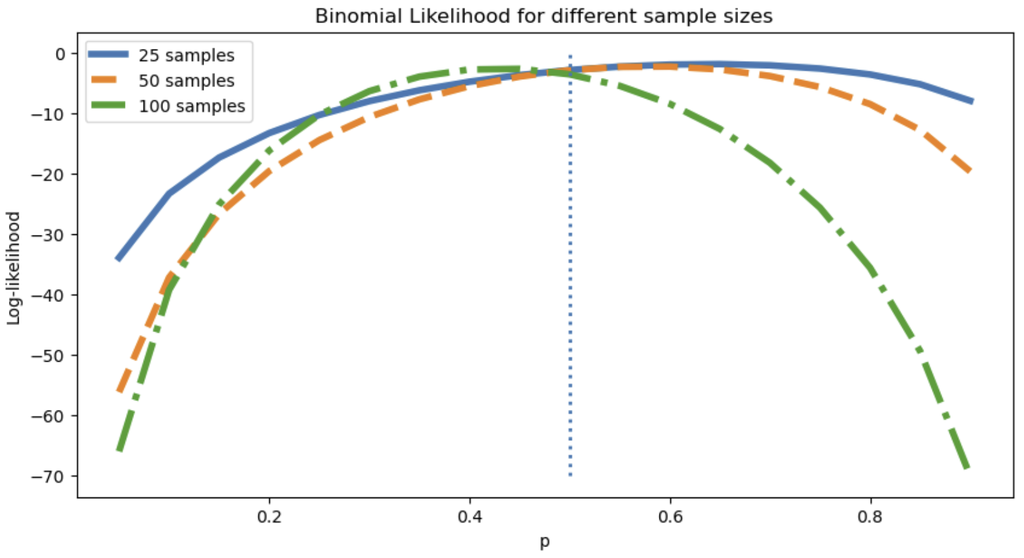

Binomial likelihood at different sample sizes

## Example: The Normal likelihood

The univariate Normal probability density function with parameter vector $\mathbf{\theta} = (\mu,\sigma)$ for a single observation, $x_i$:

$$f(x_i\ |\ \mu,\sigma^2) = -\frac{1}{(2
\pi \sigma^2)^{1/2}} exp\Big[ - \frac{1}{2 \sigma^2} (x_i - \mu)^2
\Big]$$
For n observations, $\mathbf{X} = x_1, x_2, \ldots, x_n$, the likelihood is the **product of the densities**:

$$\mathcal{L}(\mathbf{X} |\
\mathbf{\theta}) = -\frac{n}{(2 \pi \sigma^2)^{1/2}} exp\Big[ -
\frac{1}{2 \sigma^2} \prod_{i=1}^n (x_i - \mu)^2 \Big]$$

The log-likelihood (log of above) is a lot easiter to deal with:

$$l(\mathbf{X}\ |\ \mu, \sigma) = -
\frac{n}{2} log( 2 \pi \sigma^2 ) - \frac{1}{2 \sigma^2} \sum_{i=1}^n
(x_i - \mu)^2$$
- The log-likelihood is a function of the parameters, $(\mu,\sigma)$

## Example: The Normal likelihood

An example to illustrate the foregoing concepts

- Plot the likelihood for 5, 10 and 20 samples from a standard Normal distribution
- Vary the parameter $\mu$, and assume the parameter $\sigma$ is fixed and known. The steps are:
  - A random sample is drawn from a standard Normal distribution
  - For the random sample the log-likelihood is computed at each parameter value
- Notice that as the number of observations increases so does the curvature of the likelihood.

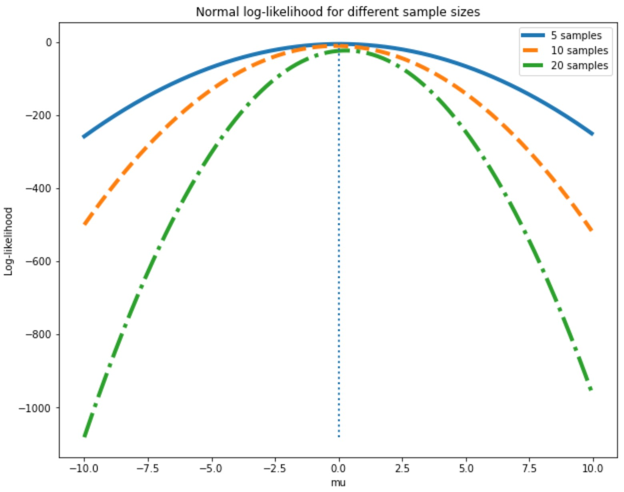

Normal likelihood at different sample sizes

## Example: Binomial Likelihood

Example of log-likelihood for the Binomial distribution

- Binomial distribution models **discrete events**
- Range of the single parameter, $\pi$, restricted to the range $0 \le \pi \le 1$
- Binomial distribution has the following probability mass function (PMF) for $k$ successes in $n$ trials:

$$f(k, n\ |\ \pi) = \binom{n}{y} \pi^k (1 - \pi)^{n-k}$$

- Log-likelihood is easily found:

$$l(k, n\ |\ \pi) = log \binom{n}{k} + k\
log(\pi) + (n-k)\ log(1-\pi)$$

- Binomial log-likelihood has a strong dependence on both the sample size, $n$ and the number of successes, $k$

## The Maximum Likehihood Estimator

**Maximum likelihood estimator (MLE)** is a foundational tool for much of statistical inference and machine learning

- Given a log-likelihood function, find the model parameters which maximize it
- Further, knowing the distribution allows us to quantify the uncertainty of the MLE parameter estimates
- The model parameter estimates found by MLE are Normal for large samples, a remarkable property
- The MLE is a **point estimator**
- An estimate of a single parameter value, or point value, with the highest likelihood

## The Maximum Likehihood Estimator

The maximum likelihood for the model parameters is achieved when two conditions are met:

$$\frac{\partial\ l(\mathbf{X}\ |\ \mathbf{\theta)})}{\partial \theta} = 0
\\
\frac{\partial^2\ l(\mathbf{X}\ |\ \mathbf{\theta)})}{\partial \theta^2}
< 0$$

Interpret these two conditions:

- First derivative of log-likelihood function, or slope, is **0 at either maximum or minimum points**:
  - In general, $\vec{\theta}$ is a vector of model parameters
  - Partial derivatives of log-likelihood are a vector - the **gradient with respect to the model parameters**
  - Gradient of the log-likelihood are known as the **score function**
- The second derivatives of the log-likelihood indicates the **curvature**
  - Maximum has negative curvature
  - Minimum has positive curvature

## Fisher information and properties of MLE

The maximum likelihood estimator has useful and desirable properties

- Start with a matrix of second partial derivatives of the log-likelihood function
- Matrix is the **observed information matrix** of the model, $\mathcal{I}(\vec{\theta})$.

$$\mathcal{I}(\vec{\theta}) =
\begin{pmatrix}
\frac{\partial^2 l(\mathbf{X}\ |\ \mathbf{\theta})}{\partial
\theta_1^2} &
\frac{\partial^2 l(\mathbf{X}\ |\ \mathbf{\theta})}{\partial \theta_2\
\partial \theta_1} &
\cdots &
\frac{\partial^2 l(\mathbf{X}\ |\ \mathbf{\theta})}{\partial \theta_n\
\partial \theta_1}\\
\frac{\partial^2 l(\mathbf{X}\ |\ \mathbf{\theta})}{\partial
\theta_1\ \partial \theta_2} &
\frac{\partial^2 l(\mathbf{X}\ |\ \mathbf{\theta})}{\partial
\theta_2^2} &
\cdots &
\frac{\partial^2 l(\mathbf{X}\ |\ \mathbf{\theta})}{\partial
\theta_2\ \partial \theta_n}\\
\vdots & \vdots & \vdots & \vdots \\
\frac{\partial^2 l(\mathbf{X}\ |\ \mathbf{\theta})}{\partial
\theta_n\ \partial \theta_1} &
\frac{\partial^2 l(\mathbf{X}\ |\ \mathbf{\theta})}{\partial
\theta_n\ \partial \theta_2} &
\cdots &
\frac{\partial^2 l(\mathbf{X}\ |\ \mathbf{\theta})}{\partial
\theta_n^2}
\end{pmatrix}$$

Useful properties of the information matrix

- The more negative the values of the second partial derivatives, the greater the curvature of the log-likelihood
  - Narrow peak implies that the information on parameter values is high
  - The matrix is symmetric, or information is symmetric around the maximum likelihood point

## Fisher information and properties of MLE

Can one consider the information of the MLE before sampling data or performing an experiment?

- Can use the **expected information** or **Fisher information**
- Fisher information is the expectation over the second derivative of the observed information
  $$\mathcal{J}(\vec{\theta}) =
  -\mathbf{E}\big\{ \mathcal{I}(\vec{\theta}) \big\} = -\mathbf{E}\big\{
  \frac{\partial^2\ l(\mathbf{X}\ |\ \mathbf{\theta})}{\partial \theta^2}
  \big\}$$

## Fisher information and properties of MLE

Fisher information leads to an important relationship

- The MLE parameter estimate $\hat{\theta}$ is a Normally distributed random variable
- Arises from the Taylor expansion of the maximum likelihood estimator

$$0 = \frac{\partial\ l(\mathbf{X}\ |\ \mathbf{\theta})}{\partial \theta}
=
\frac{\partial\ l(\theta)_\mathbf{X}}{\partial \theta} +
\frac{\partial^2\ l(\hat{\theta})_\mathbf{X}}{\partial \theta^2}
(\hat{\theta} - \theta)$$
or

$$0 = l'(\theta)_\mathbf{X} + l''(\hat{\theta})_\mathbf{X}
(\hat{\theta} - \theta)$$

- $l'(\theta)_\mathbf{X}$: first partial derivative given observations $\mathbf{X}$
- $l''(\hat{\theta})_\mathbf{X}$: second partial derivative given observations $\mathbf{X}$

## Fisher information and properties of MLE

Continuing with the simplified notation, and solving for $\hat{\theta}$;

$$\hat{\theta} = \theta +
\frac{l'(\theta)_\mathbf{X}/n}{-l''(\hat{\theta})_\mathbf{X}/n}$$

Fisher information relates to the **score function** as the inverse variance

$$\frac{\partial\ l(\theta)_{\mathbf{X}}}{ \partial \theta}\ \dot{\sim}\
\mathcal{N} \big(0, 1/ \mathcal{I}_\theta \big)$$

For **large sample**, $n \rightarrow \infty$, take the expectation over all samples, $\mathbf{X}$. Assuming first and second derivatives exist and continuous, then by the Central Limit Theorem:

$$\hat{\theta} \dot{\sim}
\mathcal{N}\Big(\theta, \frac{1}{n\mathcal{I}(\theta)}
\Big)$$

## Fisher information and properties of MLE

$$\frac{\partial\ l(\theta)}{ \partial \theta}\ \dot{\sim}\
\mathcal{N} \big(0, 1/ \mathcal{I}_\theta \big)$$

Relationship shows several important properties

- The maximum likelihood estimate of model parameters, $\hat{\theta}$, is Normally distributed
- The larger the Fisher information, the lower the variance of the parameter estimate
  - Greater curvature of the log likelihood function gives more certain the parameter estimates
  - The variance of the parameter estimate is inversely proportional to the number of samples, $n$.

## Example of MLE for Normal distribution

MLE for the Normal distribution

- Find derivatives of the log-likelihood function with respect to the model parameters, $\mu$ and $\sigma2$

$$\begin{pmatrix}
\frac{\partial l}{\partial \mu} \\
\frac{\partial l}{\partial \sigma^2}
\end{pmatrix}
=
\begin{pmatrix}
\frac{1}{\sigma^2} \sum_j (x_j - \mu) \\
-\frac{n}{2 \sigma^2} +
\frac{1}{2 \sigma^4} \sum_j (x_j - \mu)^2
\end{pmatrix}
=
\begin{pmatrix}
0 \\ 0
\end{pmatrix}$$

Solving above for the estimate of the mean, $\bar{x}$

$$\sum_{j=1}n (x_j - \mu) = 0$$
$$\bar{x} \rightarrow \mu:\ at\ convergence\\
\bar{x} = \frac{1}{n} \sum_{j=1} x_j$$

## Example of MLE for Normal distribution

MLE for the Normal distribution

$$\begin{pmatrix}
\frac{\partial l}{\partial \mu} \\
\frac{\partial l}{\partial \sigma^2}
\end{pmatrix}
=
\begin{pmatrix}
\frac{1}{\sigma^2} \sum_j (x_j - \mu) \\
-\frac{n}{2 \sigma^2} +
\frac{1}{2 \sigma^4} \sum_j (x_j - \mu)^2
\end{pmatrix}
=
\begin{pmatrix}
0 \\ 0
\end{pmatrix}$$

Find the maximum likelihood estimate of $\sigma^2$

$$\frac{1}{s^2} \sum_{j=1} (x_j - \mu)^2 = n$$
$$\bar{x} \rightarrow \mu:\ at\ convergence\\
s^2 = \frac{1}{n} \sum_{j=1}^n (x_j - \bar{x})^2$$
Adding the bias correction of the 1 DoF used to compute $\bar{x}$, we finally get:

$$\bar{x} \rightarrow \mu:\ at\ convergence\\
s^2 = \frac{1}{n-1} \sum_{j=1}^n (x_j - \bar{x})^2$$

## Example of MLE for Normal distribution

$$\begin{align}
\mathcal{J}(\vec{\theta}) &= - \mathbf{E}
\begin{pmatrix}
\frac{\partial^2 l}{\partial \mu^2} & \frac{\partial^2 l}{\partial
\mu\ \partial \sigma^2}\\
\frac{\partial^2 l}{\partial \mu\ \partial \sigma^2} &
\frac{\partial^2 l}{\partial (\sigma^2)^2}
\end{pmatrix} \\
&= - \mathbf{E}
\begin{pmatrix}
-\frac{n}{\sigma^2} & -\frac{n}{\sigma^4}(\bar{x} - \mu) \\
-\frac{n}{\sigma^4}(\bar{x} - \mu) & -\frac{n}{2\sigma^4} +
\frac{1}{\sigma^6} \sum_j (x_j - \mu)^2
\end{pmatrix} \\
&=
\begin{pmatrix}
\frac{n}{\sigma^2} & 0 \\
0 & \frac{n}{2\sigma^4}
\end{pmatrix}
\end{align}$$

The simplification results from the facts that in the limit of a large sample by the law of large numbers:

$$\begin{align}
\bar{x} &\rightarrow \mathbf{E}(\mathbf{x_j}) = \mu\\
s^2 &\rightarrow \mathbf{E} \big\{ (x_j - \mu)^2 \big\} = \sigma^2
\end{align}$$

# Example of MLE for Normal distribution

$$\mathcal{J}(\vec{\theta}) = \begin{pmatrix}
\frac{n}{\sigma^2} & 0 \\
0 & \frac{n}{2\sigma^4}
\end{pmatrix}$$

There are some aspects of these relationships which make the MLE method attractive:

- The curvature of the MLE for both parameters increases with the number of samples $n$
- The peak of the log-likelihood function becomes better defined as $n$ increases.
- The maximum likelihood estimates of the parameters, $\mu$ and $\sigma^2$ are independent. The off-diagonal terms are $0$.

## Fisher information and properties of MLE

Example of Fisher Information for Normal distribution

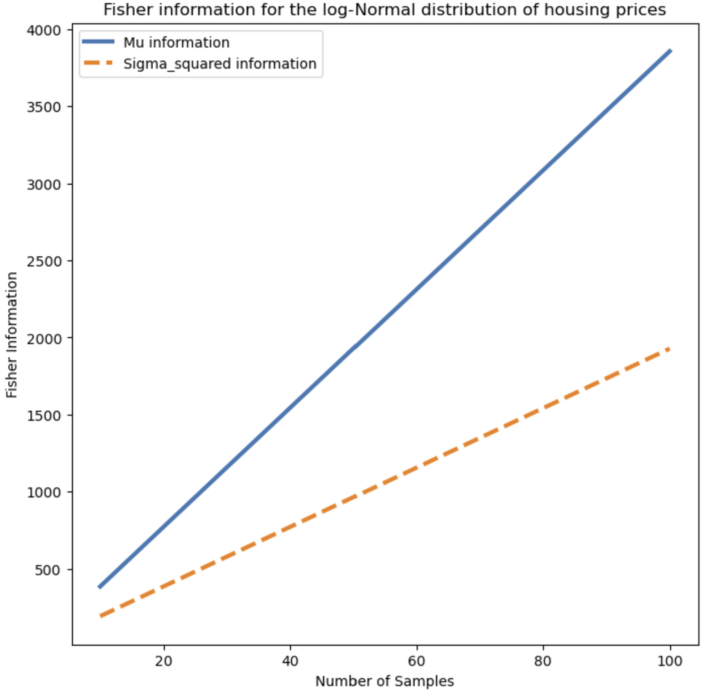

Fisher Information for Normal distribution at different sample sizes

## Finding Solutions Without a Closed Form

How do we generalize the MLE method beyond cases with a closed form solution

- For example, logistic regression has a nonlinear log likelihood function
- An approximate solution can be found by numerical **optimization methods** or **root finding methods**
- Two widely used methods
  - Gradient descent, a first-order method
  - Newton’s method, quadratic approximation

## Gradient descent methods

The gradient descent method finds the maximum of the log-likelihood function by following the gradient ‘uphill’

- Start with the gradient of the log-likelihood function with respect to the parameters, $\theta$
- The gradient is the vector of partial derivatives with respect to each of the parameters

$$grad(l(\vec{\theta})) = \nabla_\theta\ l(\vec{\theta}) =
\begin{pmatrix}
\frac{\partial l(\mathbf{X}\ |\ \mathbf{\theta})}{\partial \theta_1}
\\
\frac{\partial l(\mathbf{X}\ |\ \mathbf{\theta})}{\partial
\theta_2}\\
\vdots \\
\frac{\partial l(\mathbf{X}\ |\ \mathbf{\theta})}{\partial \theta_n}
\end{pmatrix}$$

- Given a current parameter estimate vector at step n , $\hat{\theta}_n$, the improved parameter estimate vector, $\hat{\theta}_{n+1}$, is found:

$$\hat{\theta}_{n+1} = \hat{\theta}_n +
\gamma\ \nabla_\theta\ l(\hat{\theta})$$

## Gradient descent methods

The gradient descent method finds the maximum of the log-likelihood function by following the gradient ‘uphill’

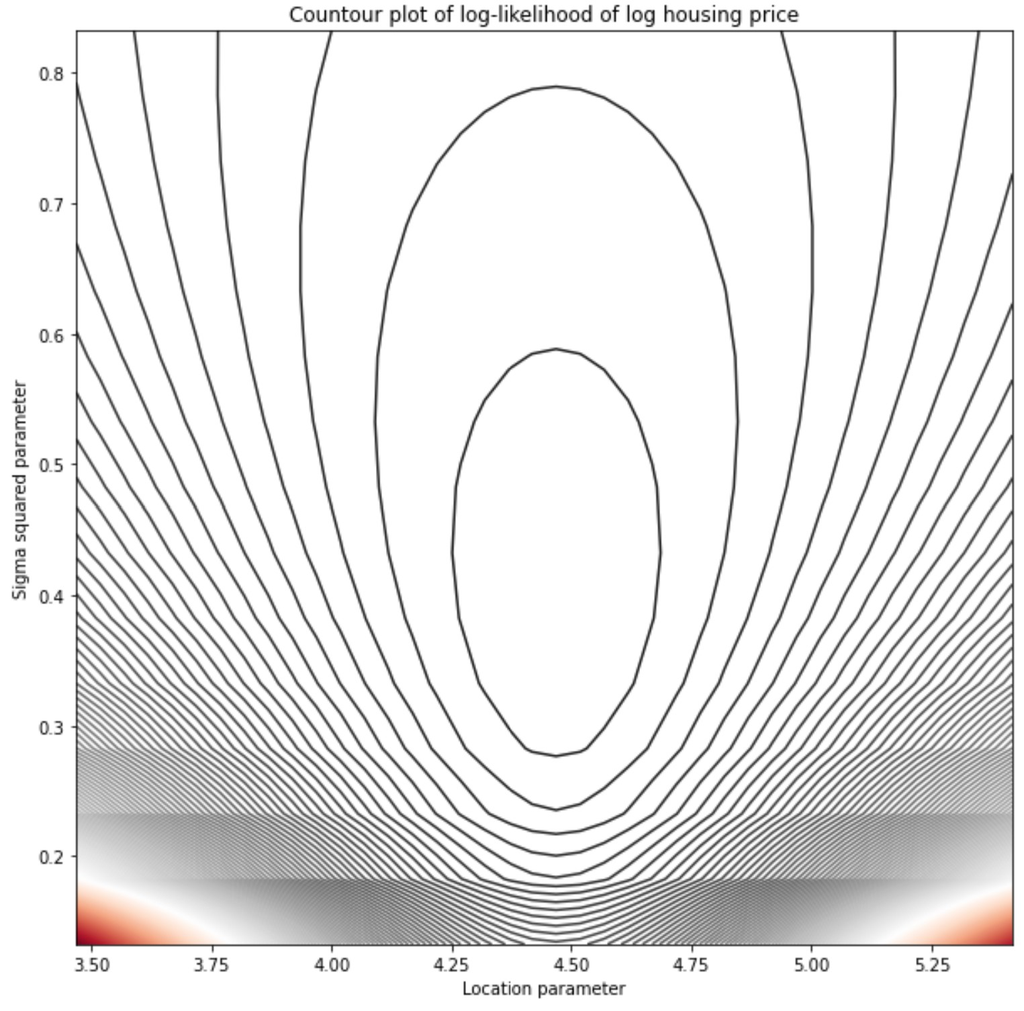

Contours of Normal Log-Likelihood

## Gradient descent methods

The gradient descent method finds the maximum of the log-likelihood function by following the gradient ‘uphill’

- Given a current parameter estimate vector at step n , $\hat{\theta}_n$, the improved parameter estimate vector, $\hat{\theta}_{n+1}$, is found:

$$\hat{\theta}_{n+1} = \hat{\theta}_n +
\gamma\ \nabla_\theta\ l(\hat{\theta})$$

- The hyperparameter $\gamma$ is the **learning rate** or **step size**
  - Determining a learning rate can have a significant effect on the performance of the gradient
  - This hyperparameter can be chosen manually, often with by a search of the hyperparameter space
- Using a fixed $\gamma$ is far from optimal
  - The gradient changes toward the maximum point the optimal step size changes
  - More sophisticated algorithms use an adaptive method to determine an optimal step at each step
  - Adaptive algorithm finds step size dynamically using a **line search** procedure

## Gradient descent methods

The gradient descent method finds the maximum of the log-likelihood function by following the gradient ‘uphill’

- Given a current parameter estimate vector at step n , $\hat{\theta}_n$, the improved parameter estimate vector, $\hat{\theta}_{n+1}$, is found:

$$\hat{\theta}_{n+1} = \hat{\theta}_n +
\gamma\ \nabla_\theta\ l(\hat{\theta})$$

- Algorithm converges when the norm of the gradient is approximately 0
- This is the **stopping condition**
- Express stopping condition as:

$$|| \nabla_\theta\ l(\vec{\theta}) ||\le tollerance$$

## Gradient descent methods

**Gradient with respect to model parameters** is computed for each dimension of the model parameter vector

```
proceedure compute_grad(theta, observations):
  for each parameter:
      grad[theta_i] = grad(theta_i, observations)
  return grad

define learning_rate
proceedure update_weights(theta, grad):
   theta = theta + learning_rate * compute_grad(theta)
   return weights
```

The forgoing procedure can be vectorized or parallelized

## Gradient descent methods

The gradient descent method finds the maximum of the log-likelihood function by following the gradient ‘uphill’

- The gradient is always perpendicular to the contours

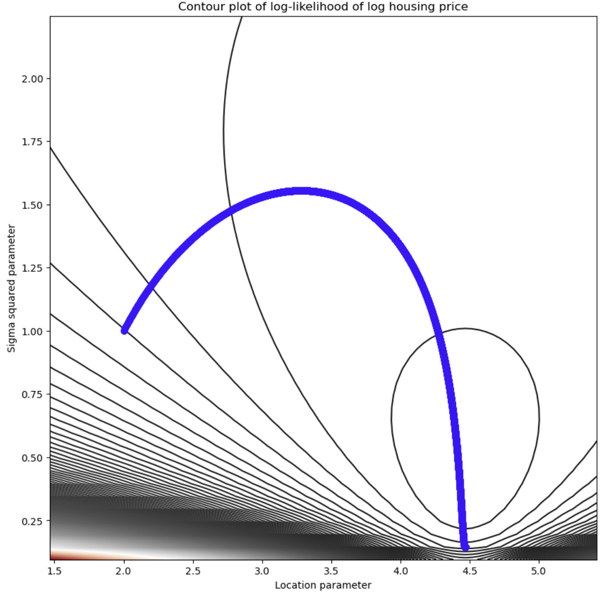

Gradient descent on countour plot of log-likelihood

## Stochastic gadient descent (SGD)

The simple gradient descent algorithm and Newton’s method have limited scalability

- Basic algorithms require computing and summing the entire gradient vector
  - Calculation must be done as a single batch in memory, or **batch gradient descent**
  - Computing the full gradient at each step limits scalability
- **Stochastic gradient decent (SGD)** algorithm computes the approximate expected gradient using a **mini-batch**
  - The mini-batch is a limited-size Bernoulli sample from the full set of cases
  - These gradient approximations are inherently noisy or stochastic, giving rise to the method’s name
- Using mini-batches greatly increases scalability
  - While gradient estimates are less accurate, these estimates can be computed very quickly
  - SGD is highly scalable and the workhorse of many large-scale statistical methods
  - Mini-batch optimization is often referred to as **online optimization** since updates as cases arrive.

## Stochastic gadient descent (SGD)

The basic idea of stochastic optimization is using a Bernoulli random sample of the data to estimate the **expected update** of the model weights

$$\theta_{t+1} = \theta_t + \gamma\
E_{\hat{p}data}\Big[ \nabla_{\theta} J(\theta_t) \Big]$$

where, $E_{\hat{p}data} \big[ \big]$ is the expected value of the gradient given the Bernoulli sample of the data $\hat{p}data$.

- Choosing batch size can require some tuning
  - If the batch is too small, the gradient estimate will be and, hardware resources may not be fully utilized
  - Large batches require significant memory and slow the calculation
- Empirically, SGD has good convergence properties
  - This behavior arises since stochastic gradient samples provide a better exploration of the loss function space
  - For very large data sets, the SGD algorithm often converges before the first pass through the data is completed

## Stochastic gadient descent (SGD)

The pseudo code for the SGD algorithm is:

```
define learning_rate
proceedure compute_expected_grad(theta, observations):
  for each parameter:
      grad[theta_i] = grad(theta_i, observations)
  return grad

proceedure update_weights(theta, grad):
   theta = theta + learning_rate * grad(theta)
   return weights

Random_sort(cases)
while(|grad| > stopping_criteria):
    mini-batch = sample_next_n(cases)
    grad = compute_expected_grad(theta, mini_batch)
    weights = update_weights(theta, grad)`
```

- If the sampling continues for more than one cycle through the cases, the samples are biased
- In practice, this small bias does not seem to mater much

## Newton’s method

**Newton’s method**, and related methods, employ a **quadratic approximation** to optimization. For MLE, Newton’s method uses both the first and second derivatives of the log-likelihood function.

Consider a nonlinear log-likelihood function, $l(\theta\ | \mathbf{X})$. We use a Taylor expansion to find the tangent point of the log-likelihood, $\theta_n = \theta_k + \delta \theta$. The Taylor expansion is:

$$l(\theta_k + \delta\theta) = l(\theta_k) + l'(\theta_k)\delta\theta
+ \frac{1}{2} l''(\theta_k)\delta\theta$$

Setting this expansion to 0, we have:

$$\begin{align}
0 &= \frac{d}{d\ \delta \theta} \Big( l(\theta_k) +
l'(\theta_k)\delta\theta + \frac{1}{2}
l''(\theta_k)\delta\theta^2 \Big)\\
0 &= l'(\theta_k) + l''(\theta_k) \delta\theta
\end{align}$$

It is simple to solve for $\delta \theta$:

$$\delta\theta = \frac{l'(\theta_k)}{l''(\theta_k)}$$

## Newton’s method

At each step in the iteration, the update $x_{n+1}$ is given by the following relationship:

$$\begin{align}
\theta_{n+1} &= \theta_n
+ \frac{l'(\theta_k)}{l''(\theta_k)}\\
&= \theta_n + \delta\theta
\end{align}$$

- Newton’s method has a quadratic form
  - The quadratic form is not just a mathematical curiosity
  - Newton’s method exhibits convergence quadratic in the number of iterations
  - Compared to the approximate linear convergence for gradient descent methods

## Newton’s method

Newton’s method in higher dimensions

- Use the gradient, $\nabla l(\vec{\theta})$ for the first derivatives of the likelihood
- Second derivative is represented as a matrix, $\nabla^2 l(\vec{\theta})$, known as the **Hessian**
- The quadratic update is:

$$x_{n+1} = x_n + \gamma |\nabla_\theta^2 l(\vec{\theta})|^{-1}
\nabla_\theta l(\vec{\theta})$$

- Requires computing the **inverse Hessian** matrix with practical difficulties
- The inverse of the Hessian may not exist as this matrix may be singular
- With large number of model parameters, the Hessian will have high dimensionality and computing inverse is computationally intensive
  - Computing the full gradient and Hessian requires summing over all observations

## Newton’s method

Newton’s method in higher dimensions

- The quadratic update is:

$$x_{n+1} = x_n + \gamma |\nabla_\theta^2 l(\vec{\theta})|^{-1}
\nabla_\theta l(\vec{\theta})$$

- For large scale problems **quasi-Newton** methods are used
- Use an approximation to avoid computing the full inverse Hessian
- **Limited-memory Broyden–Fletcher–Goldfarb–Shanno (L-BFGS)** algorithm the most widely used quasi-Newton method

## Limitations of MLE

The maximum likelihood estimator has a number of important limitations, including

- Incorrect model for complex distributions
- Parameter near limits
- High dimensional problems
- Correlated features

## Incorrect model and complex distributions

In many real-world problems the distribution are not simple

- Problematic for maximum likelihood methods
- Consider a likelihood function that is only approximately correct
  - Population being modeled has a different distribution
  - Outliers in the form of erroneous samples
- Example; maximum likelihood estimator for population with a mixture of simple distributions
  - Mixture has multiple modes
  - One mode is the maximum
- Mode found by any gradient-based algorithm is dependent on the starting point
  - MLE algorithm will find the nearest **local maximum**
  - No guarantee of finding the actual maximum likelihood point

## Incorrect model and complex distributions

Example; univariate Normal maximum likelihood estimator for mixture of 3 Normal distributions

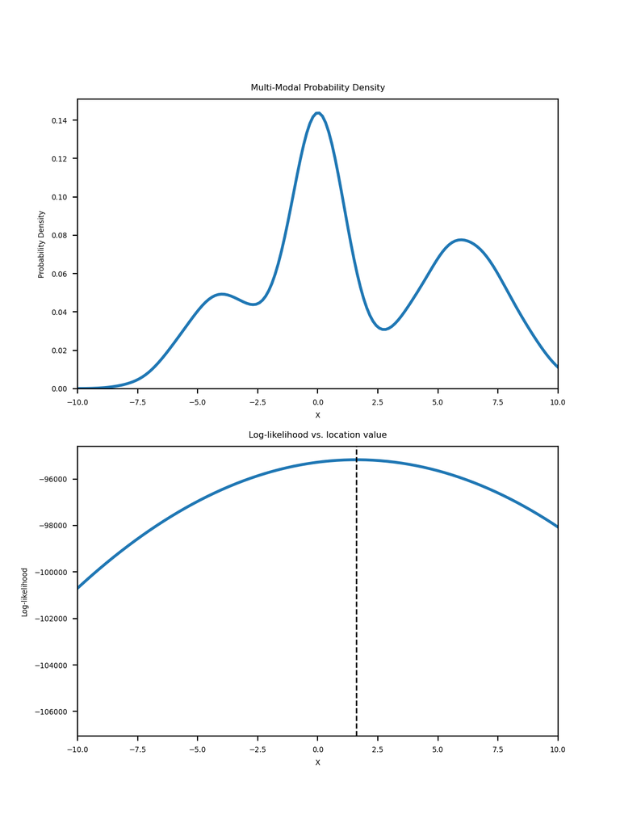

## Parameter near limits

For many distributions, parameter values have limits

- The log-likelihood function may have an extremely high gradient near the limit
  - Results can be poorly determined parameter estimates and slow convergence
  - Fisher information drops rapidly near these limits, indicating poorly determined gradient
- Examples:
  - Variance estiamtes near 0; variables with low variance
  - Binomial parameter estimates near $p=0$ and $p=1$; case with either very few successes or failure

## Parameter near limits

Example; Binomial likelihood and Fisher information with $p=0.5$  
Extreme gradients and low information near limits, $p=0$ and $p=1$

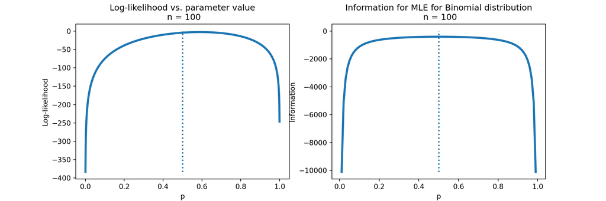

## High dimensional problems

The MLE method often finds poor solutions to problems in high dimensions

- High dimensions means a large numbers of parameters
  - The likelihood function has corresponding high dimensionality; one dimension for each parameter
- For high dimensional problems, it is often the case that the gradient and Hessian are not well determined
  - Uncertainty in the variables can lead to considerable uncertainty in determining the gradient in high dimensions
  - MLE algorithms may not converge or converge to results with a large uncertainty
- Even with few parameters, MLE methods can have convergence problems
  - Example; difficulties fitting the variance parameter while fitting the location parameter for a univariate Normal distribution
- We will discuss this problem later in the course

## Correlated features

Theory assumes that the variables used for MLE are independent

- In reality, never truly the case
- Some variables have a high correlation to each other
- MLE algorithm can breakdown since gradients will not be well determined
- We will discuss this problem later in the course

## Summary

- Likelihood is a measure of how well a **parametric model** fits a data sample

$$\mathcal{L}(\mathbf{X} |\
\mathbf{\theta}) = \prod_{i=1}^n f(x_i | \mathbf{\theta})$$

- In most practical cases, we work with the **log likelibood**

$$l(\mathbf{X} |\ \mathbf{\theta}) =
log\big( \mathcal{L}(\mathbf{X} |\ \mathbf{\theta}) \big) = \sum_{j} log
\Big( f(x_j\ |\ \theta) \Big)$$

## Summary

- Matrix is the **observed information matrix** of the model, $\mathcal{I}(\vec{\theta})$.
- The more negative the values of the second partial derivatives, the greater the curvature of the log-likehihood
- Fisher information or **expected information** is the expectation over the second derivative of the observed information

$$\mathcal{J}(\vec{\theta}) =
-\mathbf{E}\big\{ \mathcal{I}(\vec{\theta}) \big\} = -\mathbf{E}\big\{
\frac{\partial^2\ l(\mathbf{X} | \theta)}{\partial \theta^2}
\big\}$$

- Fisher information relates to the score function as its variance

$$\frac{\partial\ l(\theta)}{ \partial \theta}\ \dot{\sim}\
\mathcal{N} \big(0, 1/ \mathcal{I}_\theta \big)$$

- For **large sample**, $n \rightarrow \infty$, take the expectation over $\mathbf{X}$:

$$\hat{\theta} \dot{\sim}
\mathcal{N}\Big(\theta, \frac{1}{n\mathcal{I}(\theta)}
\Big)$$

- The maximum likelihood estimate of model parameters, $\hat{\theta}$, is Normally distributed
- The larger the Fisher information, the lower the variance of the parameter estimate
  - Greater curvature of the log likelihood function gives more certain the parameter estimates
  - The variance of the parameter estimate is inversely proportional to the number of samples, $n$

## Summary

- The gradient descent method finds the maximum of the log-likelihood function by following the gradient ‘uphill’
- The maximum likelihood for the model parameters is achieved when two conditions are met:

$$\frac{\partial\ l(\mathbf{X}\ |\ \mathbf{\theta)})}{\partial \theta} = 0
\\
\frac{\partial^2\ l(\mathbf{X}\ |\ \mathbf{\theta)})}{\partial \theta^2}
< 0$$

- Gradient of the log-likelihood is known as the score function

$$grad(l(\vec{\theta})) = \nabla_\theta\ l(\vec{\theta}) =
\begin{pmatrix}
\frac{\partial l(\mathbf{X}\ |\ \mathbf{\theta})}{\partial \theta_1}
\\
\frac{\partial l(\mathbf{X}\ |\ \mathbf{\theta})}{\partial
\theta_2}\\
\vdots \\
\frac{\partial l(\mathbf{X}\ |\ \mathbf{\theta})}{\partial \theta_n}
\end{pmatrix}$$

## Summary

- The gradient descent method finds the maximum of the log-likelihood function by following the gradient ‘uphill’
- Given a current parameter estimate vector at step n , $\hat{\theta}_n$, the improved parameter estimate vector, $\hat{\theta}_{n+1}$, is found:

$$\hat{\theta}_{n+1} = \hat{\theta}_n +
\gamma\ \nabla_\theta\ l(\hat{\theta})$$

- The hyperparameter $\gamma$ is the **learning rate** or **step size**
- Stochastic optimization uses a Bernoulli random sample of the data to estimate the **expected update** of the model weights

$$\theta_{t+1} = \theta_t + \gamma\
E_{\hat{p}data}\Big[ \nabla_{\theta} J(\theta_t) \Big]$$

- Where, $E_{\hat{p}data} \big[ \big]$ is the expected value of the gradient given the Bernoulli sample of the data, $\hat{p}data$.
- Empirically, SGD has good convergence properties

## Summary

- **Newton’s method**, and related methods, employ a **quadratic approximation** to optimization.
- Newton’s method exhibits convergence quadratic in the number of iterations
  - Compared to the approximate linear convergence for gradient descent methods
- The quadratic update is:

$$x_{n+1} = x_n + \gamma |\nabla_\theta^2 l(\vec{\theta})|^{-1}
\nabla_\theta l(\vec{\theta})$$

- $\gamma$ is a learning rate of step size
- Requires computing the **inverse Hessian** matrix with practical difficulties
  - The inverse of the Hessian may not exist as this matrix may be singular
  - With large number of model parameters, the Hessian will have high dimensionality and computing inverse is computationally intensive
- For large scale problems **quasi-Newton** methods are used
  - Use an approximation to avoid computing the full inverse Hessian
  - **Limited-memory Broyden–Fletcher–Goldfarb–Shanno (L-BFGS)** algorithm the most widely used quasi-Newton method

## Summary

The maximum likelihood estimator has a number of important limitations, including

- Incorrect model and complex distributions
- Parameter near limits
- High dimensional problems
- Correlated features